# Проект - Выбор локации для скважины

#### Датасет *df_geo_1*

```python
df_geo_1.head()
```

| id | f0 | f1 | f2 | product |
| --- | --- | --- | --- | --- |
| kBEdx | -15.001348 | -8.276000 | -0.005876 | 3.179103 |
| 62mP7 | 14.272088 | -3.475083 | 0.999183 | 26.953261 |
| vyE1P | 6.263187 | -5.948386 | 5.001160 | 134.766305 |
| KcrkZ | -13.081196 | -11.506057 | 4.999415 | 137.945408 |
| AHL4O | 12.702195 | -8.147433 | 5.004363 | 134.766305 |

Построим графики распределения признаков датасета *df_geo_1*.

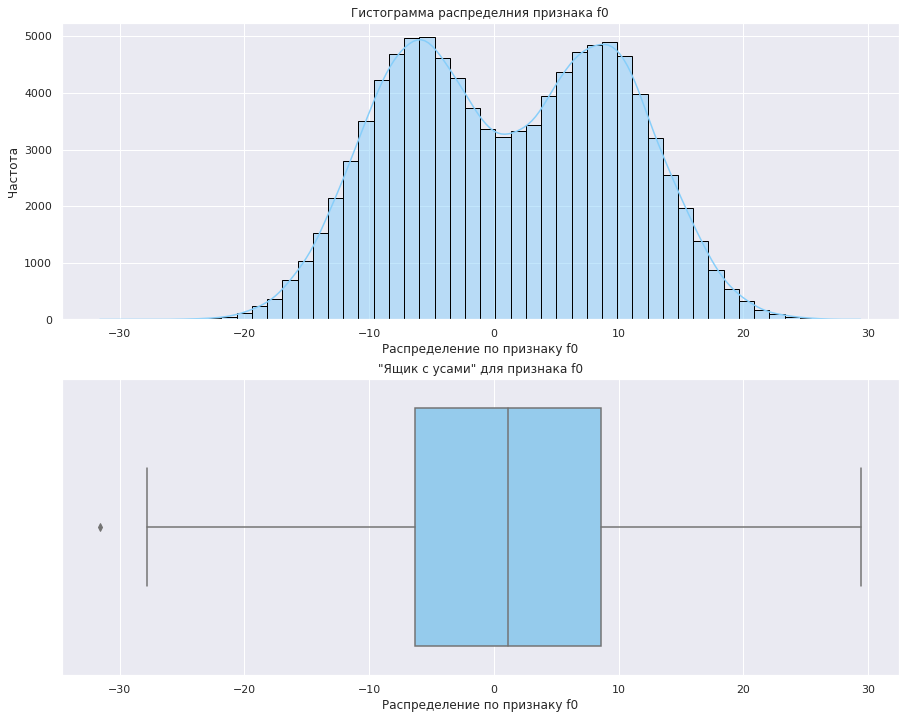

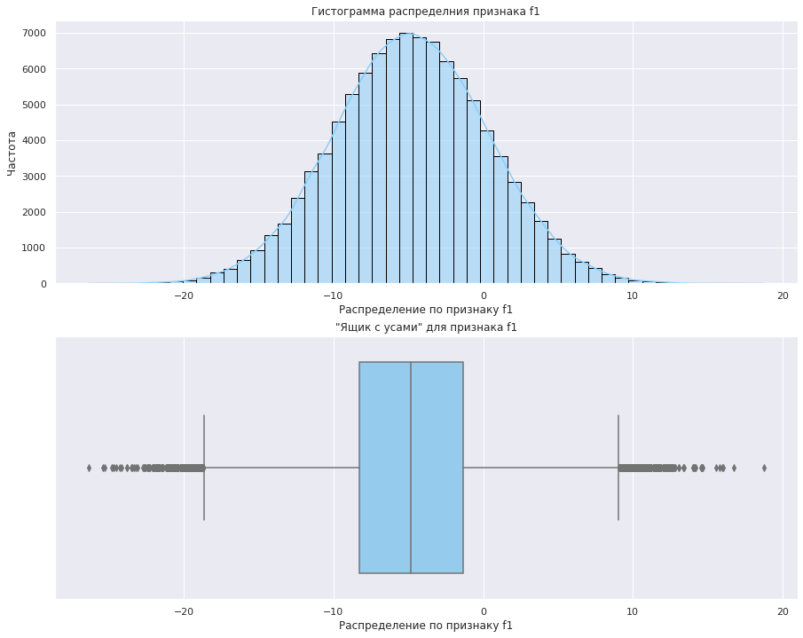

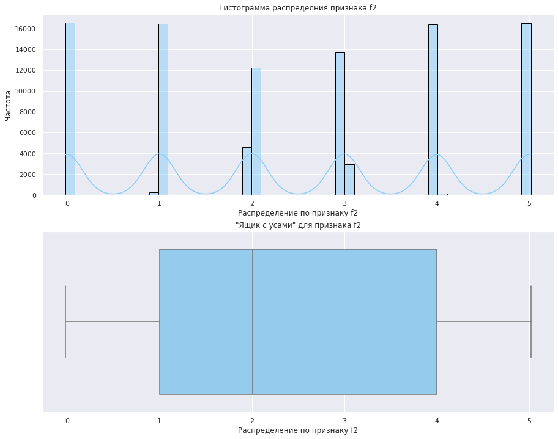

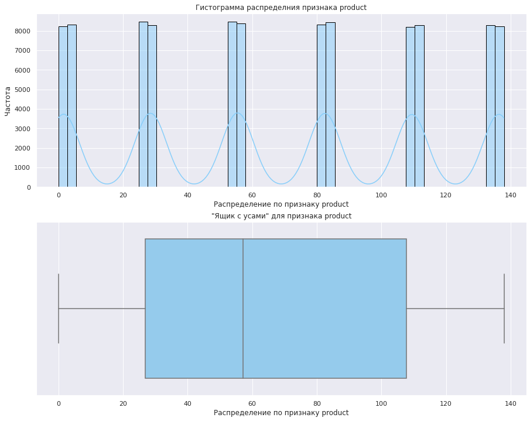

```python
df_all_num_graphics(df_geo_1)
```

```python
df_geo_1.describe()
```

|  | f0 | f1 | f2 | product |
| --- | --- | --- | --- | --- |
| count | 100000.000000 | 100000.000000 | 100000.000000 | 100000.000000 |
| mean | 1.141296 | -4.796579 | 2.494541 | 68.825000 |
| std | 8.965932 | 5.119872 | 1.703572 | 45.944423 |
| min | -31.609576 | -26.358598 | -0.018144 | 0.000000 |
| 25% | -6.298551 | -8.267985 | 1.000021 | 26.953261 |
| 50% | 1.153055 | -4.813172 | 2.011479 | 57.085625 |
| 75% | 8.621015 | -1.332816 | 3.999904 | 107.813044 |
| max | 29.421755 | 18.734063 | 5.019721 | 137.945408 |

Таким образом, видим, что в датасете *df_geo_1*:

- Среднее значение признака `f0` - 1,14 усл.ед., минимальное значение -31,6, максимальное - 29,42 усл.ед.. Распределение значений имеет бимодальный вид, медиана - 1,15 усл.ед., стандарное отклонение - 8,97 усл.ед.;
- Среднее значение признака `f1` - -4,8 усл.ед., минимальное значение -26,36, максимальное - 18,73 усл.ед. Распределение значений имеет нормальный вид, медиана - -4,81 усл.ед., стандарное отклонение - 5,12 усл.ед.;
- Среднее значение признака `f2` - 2,5 усл.ед., минимальное значение -0,02, максимальное - 5,02 усл.ед. Медиана - 2,01 тыс.бар.;
- Среднее значение признака `product` - 68,83 тыс.бар., минимальное значение 0 тыс.бар, максимальное - 137,95 тыс.бар. Медиана - 57.09 тыс.бар.;

#### Датасет *df_geo_2*

```python
df_geo_2.head()
```

| id | f0 | f1 | f2 | product |
| --- | --- | --- | --- | --- |
| fwXo0 | -1.146987 | 0.963328 | -0.828965 | 27.758673 |
| WJtFt | 0.262778 | 0.269839 | -2.530187 | 56.069697 |
| ovLUW | 0.194587 | 0.289035 | -5.586433 | 62.871910 |
| q6cA6 | 2.236060 | -0.553760 | 0.930038 | 114.572842 |
| WPMUX | -0.515993 | 1.716266 | 5.899011 | 149.600746 |

Построим графики распределения признаков датасета *df_geo_2*.

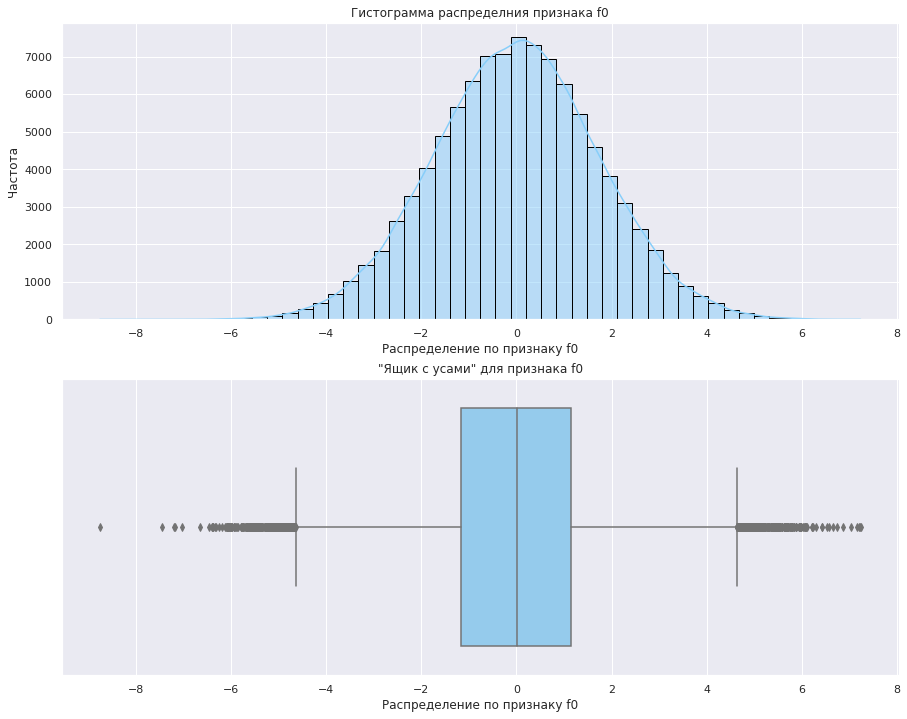

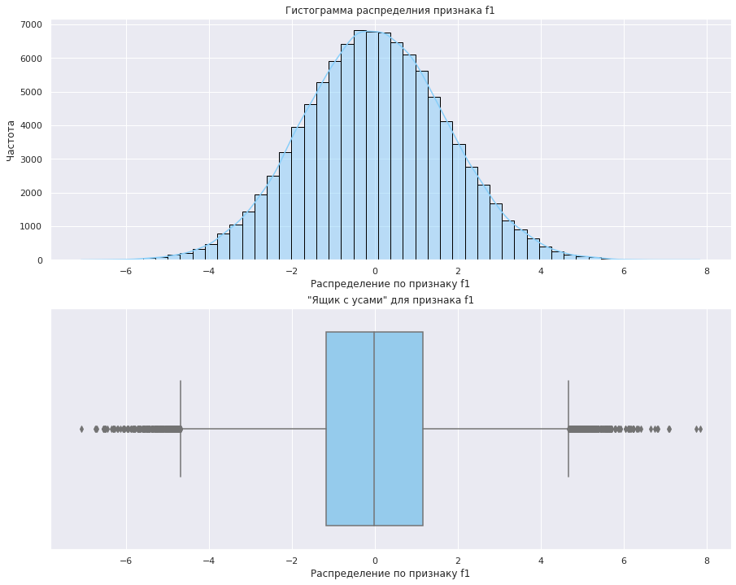

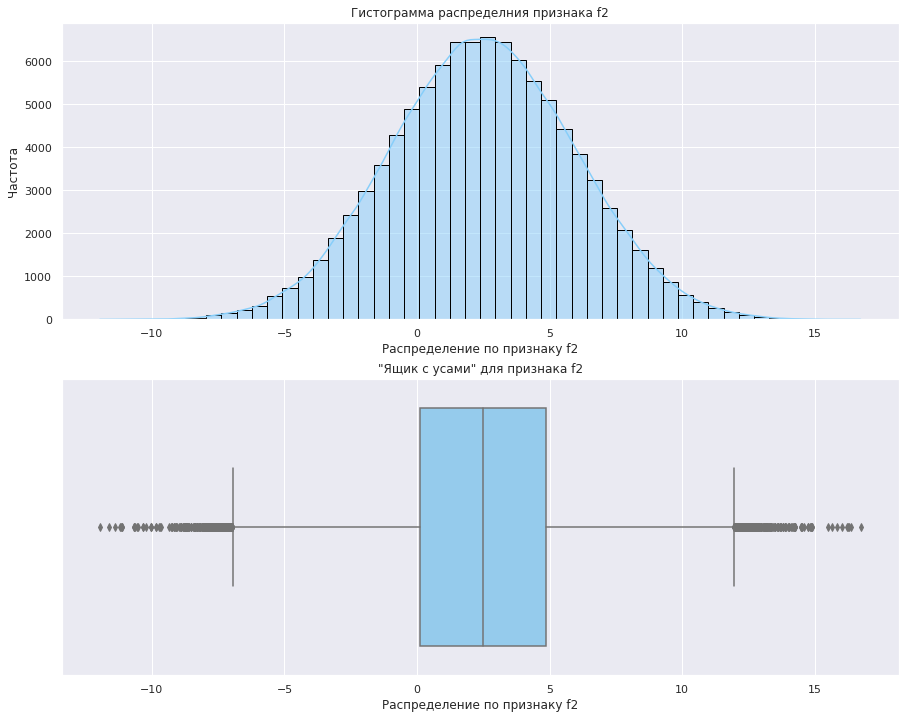

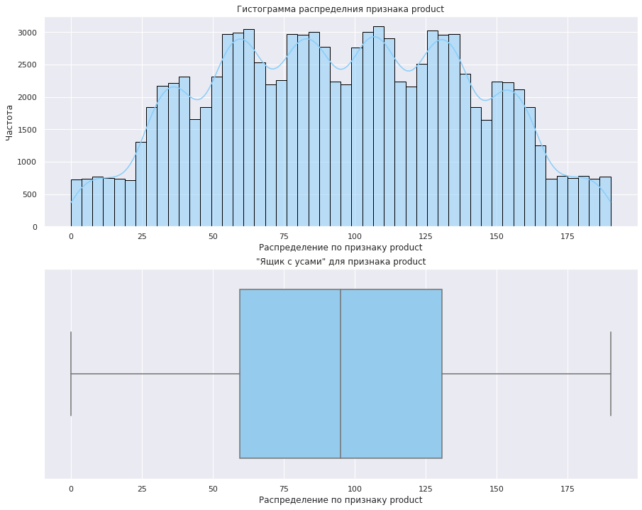

```python
df_all_num_graphics(df_geo_2)
```

```python
df_geo_2.describe()
```

|  | f0 | f1 | f2 | product |
| --- | --- | --- | --- | --- |
| count | 100000.000000 | 100000.000000 | 100000.000000 | 100000.000000 |
| mean | 0.002023 | -0.002081 | 2.495128 | 95.000000 |
| std | 1.732045 | 1.730417 | 3.473445 | 44.749921 |
| min | -8.760004 | -7.084020 | -11.970335 | 0.000000 |
| 25% | -1.162288 | -1.174820 | 0.130359 | 59.450441 |
| 50% | 0.009424 | -0.009482 | 2.484236 | 94.925613 |
| 75% | 1.158535 | 1.163678 | 4.858794 | 130.595027 |
| max | 7.238262 | 7.844801 | 16.739402 | 190.029838 |

Таким образом, видим, что в датасете *df_geo_2*:

- Среднее значение признака `f0` - 0,002 усл.ед., минимальное значение -8,8, максимальное - 7,24 усл.ед.. Распределение значений имеет нормальный вид, медиана - 0,009 усл.ед., стандарное отклонение - 1,73 усл.ед.;
- Среднее значение признака `f1` - -0,002 усл.ед., минимальное значение -7,08, максимальное - 7,84 усл.ед. Распределение значений имеет нормальный вид, медиана - -0,009 усл.ед., стандарное отклонение - 1,73 усл.ед.;
- Среднее значение признака `f2` - 2,5 усл.ед., минимальное значение -12,0, максимальное - 16,74 усл.ед. Распределение значений имеет нормальный вид, медиана - 2,5 усл.ед., стандарное отклонение - 3,5 усл.ед.;
- Среднее значение признака `product` - 95,0 тыс.бар., минимальное значение 0 тыс.бар, максимальное - 190,03 тыс.бар. Медиана - 94.93 тыс.бар.;